# Sampling Distribution, Central Limit Theorem, and Bootstrapping

## Exercise 3: Sampling distribution

Check out the resulting **500** bootstrapped sample models:

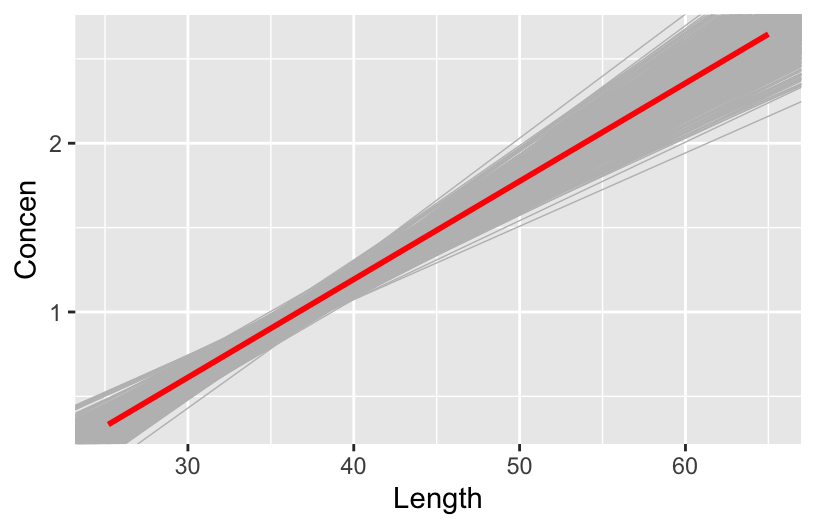

```r
# Set the seed so that we all get the same results
set.seed(155)

# Store the sample models
sample_models_boot <- map_df(1:500, function(i){
    fish %>%
    sample_n(size = 171, replace = TRUE) %>%
    lm(Concen ~ Length, data = .) %>%
    coef()
})

fish %>%
  ggplot(aes(x = Length, y = Concen)) +
  geom_smooth(method = "lm", se = FALSE) +
  geom_abline(data = sample_models_boot,
              aes(intercept = `(Intercept)`, slope = Length),
              color = "gray", size = 0.25) +
  geom_smooth(method = "lm", color = "red", se = FALSE)
```

Let’s focus on the slopes of these 500 sample models.

A plot of the 500 slopes *approximates* the **sampling distribution** of the sample slopes.

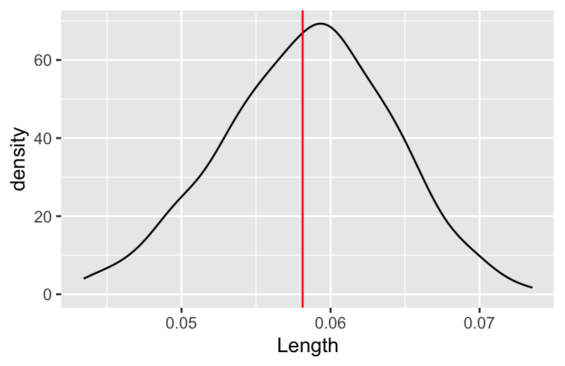

```r
sample_models_boot %>%
  ggplot(aes(x = Length)) +
  geom_density() +
  geom_vline(xintercept = 0.05813, color = "red")
```

Describe the sampling distribution:

1. What’s its general shape?
2. Where is it roughly centered?
3. Roughly what’s its spread / i.e. what’s the range of estimates you observed?

## Exercise 4: Standard error

For a more rigorous assessment of the spread among the sample slopes, let’s calculate their standard deviation:

```r
sample_models_boot %>%
  summarize(sd(Length))
## # A tibble: 1 × 1
##   `sd(Length)`
##          <dbl>
## 1      0.00569
```

Recall: The standard deviation of sample estimates is called a **“standard error”**.

It measures the typical distance of a sample estimate from the actual population value.

Compare the bootstrapped standard error to the standard error reported from our regression model (see the `Std. Error` column):

```r
coef(summary(fish_model))
##                Estimate  Std. Error   t value     Pr(>|t|)
## (Intercept) -1.13164542 0.213614796 -5.297598 3.617750e-07
## Length       0.05812749 0.005227593 11.119359 6.641225e-22
```

Are they roughly equivalent?

> Your response here

## Exercise 5: Central Limit Theorem (CLT)

Recall that the CLT assumes that, so long as our sample size is “big enough”, the sampling distribution of the sample slope will be Normal.

Specifically, all possible sample slopes will vary Normally around the population slope.

- Do your simulation results support this assumption? Why or why not?
- Want more intuition into the CLT? Watch this video explanation using bunnies and dragons: https://www.youtube.com/watch?v=jvoxEYmQHNM

## Exercise 6: Using the CLT

Let $\hat{\beta}_1$ be an estimate of the (super)population slope parameter $\beta_1$ calculated from a sample of 10 fish (`sample_models_10`).

Estimate the standard error of the slope from these resampled estimates

```r
sample_models_10 %>%
  summarize(sd(Length))
## # A tibble: 1 × 1
##   `sd(Length)`
##          <dbl>
## 1       0.0253
```

You should get a SE of *roughly* 0.026.

Thus, by the CLT, the sampling distribution of $\hat{\beta}_1$ is:

$$\hat{\beta}_1 \sim N(\beta_1, 0.026^2)$$

Use this result with the 68-95-99.7 property of the Normal model to understand the potential error in a slope estimate.

1. There are many possible samples of 10 fish. What percent of these will produce an estimate $\hat{\beta}_1$ that’s within 0.052, i.e. *2 standard errors*, of the actual population slope $\beta_1$?
2. More than 2 standard errors from $\beta_1$?
3. More than 0.079, i.e. 3 standard errors, *above* $\beta_1$?

## Exercise 7: CLT and the 68-95-99.7 Rule

Fill in the blanks below to complete some general properties assumed by the CLT:

- ___% of samples will produce $\hat{\beta}_1$ estimates within **1 st. err.** of $\beta_1$
- ___% of samples will produce $\hat{\beta}_1$ estimates within **2 st. err.** of $\beta_1$
- ___% of samples will produce $\hat{\beta}_1$ estimates within **3 st. err.** of $\beta_1$

### Exercise 8: Increasing sample size

Now that we trust bootstrapping simulations to provide reasonable insight into sampling distributions (they agree with the CLT!), let’s use them to explore the impact of **sample size** on the quality of our sample estimates. Recall our different (bootstrap) sample estimates when we started with a sample of 171 fish:

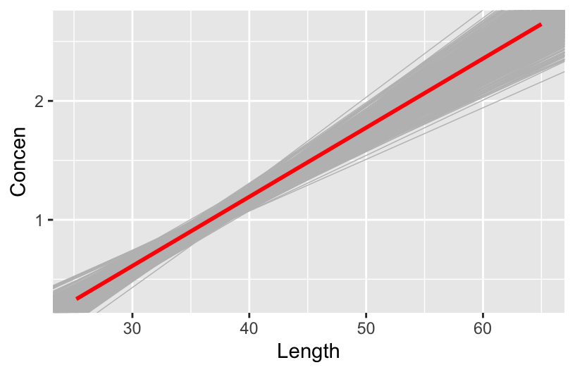

```r
# All bootstrap sample models
fish %>%
  ggplot(aes(x = Length, y = Concen)) +
  geom_smooth(method = "lm", se = FALSE) +
  geom_abline(data = sample_models_boot,
              aes(intercept = `(Intercept)`, slope = Length),
              color = "gray", size = 0.25) +
  geom_smooth(method = "lm", color = "red", se = FALSE)
```

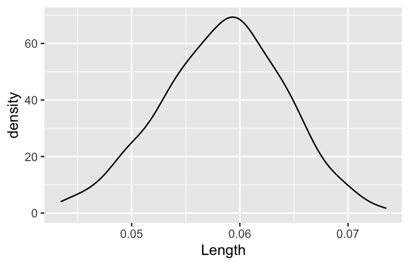

```r
# Slopes of all bootstrap sample models
sample_models_boot %>%
  ggplot(aes(x = Length)) +
  geom_density()
```

Suppose that instead of starting with n = 171 fish, we only had a sample of n = 50 or n = 20 fish! What impact do you *anticipate* this having on our sample estimates:

- If we had a smaller sample, how would it impact the sample model lines (top plot): Do you expect there to be more or less variability among the sample model lines?
- If we had a smaller sample, how would it impact the sampling distribution of the sample slopes (bottom plot):
  - Around what value to you expect it be centered?
  - What general shape do you expect it to have?
  - Do you expect it to be narrower (with smaller standard error) or wider (with larger standard error)?

### Exercise 9: 500 samples of size n

Let’s decrease the sample size in our simulation. First, take 500 REsamples from `fish`, but this time make each resample just 50 fish. Then build a sample model from each sample:

```r
set.seed(155)
sample_models_50 <- map_df(1:500, function(i){
    fish %>%
    sample_n(size = 50, replace = TRUE) %>%
    lm(Concen ~ Length, data = .) %>%
    coef()
})

# Check it out
# Make sure that your first Intercept estimate is -1.9990216
head(sample_models_50)
## # A tibble: 6 × 2
##   `(Intercept)` Length
##           <dbl>  <dbl>
## 1        -2.00  0.0795
## 2        -1.16  0.0589
## 3        -2.05  0.0811
## 4        -1.61  0.0697
## 5        -1.11  0.0542
## 6        -0.563 0.0423
```

Similarly, take 500 REsamples of size *20* from `fish`, then build a sample model from each sample:

```r
set.seed(155)
sample_models_20 <- map_df(1:500, function(i){
    fish %>%
    sample_n(size = 20, replace = TRUE) %>%
    lm(Concen ~ Length, data = .) %>%
    coef()
})

# Check it out
# Make sure that your first Intercept estimate is -2.2383596
head(sample_models_20)
## # A tibble: 6 × 2
##   `(Intercept)` Length
##           <dbl>  <dbl>
## 1        -2.24  0.0847
## 2        -2.40  0.0884
## 3        -1.09  0.0559
## 4        -0.565 0.0431
## 5        -1.50  0.0696
## 6        -2.29  0.0894
```

### Exercise 10: Impact of sample size (part I)

Use the 3 plots below to compare and contrast the 500 sets of sample models when using samples of size 20, 50, and 171. What happens as we increase sample size?! Was this what you expected?

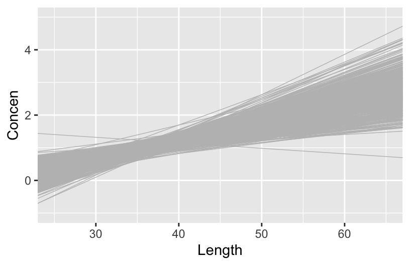

```r
# 500 sample models using samples of size 20
fish %>%
  ggplot(aes(x = Length, y = Concen)) +
  geom_smooth(method = "lm", se = FALSE) +
  geom_abline(data = sample_models_20,
              aes(intercept = `(Intercept)`, slope = Length),
              color = "gray", size = 0.25) +
  lims(x = c(25, 65), y = c(-1, 5))
```

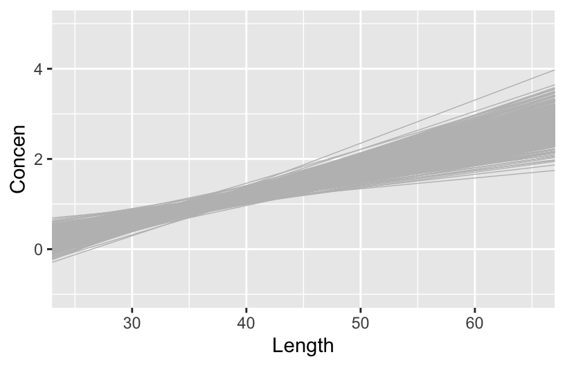

```r
# 500 sample models using samples of size 50
fish %>%
  ggplot(aes(x = Length, y = Concen)) +
  geom_smooth(method = "lm", se = FALSE) +
  geom_abline(data = sample_models_50,
              aes(intercept = `(Intercept)`, slope = Length),
              color = "gray", size = 0.25) +
  lims(x = c(25, 65), y = c(-1, 5))
```

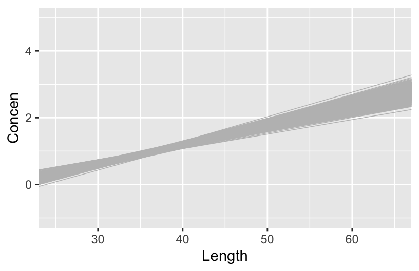

```r
# 500 sample models using samples of size 171
fish %>%
  ggplot(aes(x = Length, y = Concen)) +
  geom_smooth(method = "lm", se = FALSE) +
  geom_abline(data = sample_models_boot,
              aes(intercept = `(Intercept)`, slope = Length),
              color = "gray", size = 0.25) +
  lims(x = c(25, 65), y = c(-1, 5))
```

### Exercise 11: Impact of sample size (part II)

Using the 3 plots below, let’s focus on just the sampling distributions of our 500 slope estimates $\hat{\beta}_1$, i.e. the slopes of the lines in the above plots. How do the shapes, centers, and spreads of these sampling distributions compare? Was this what you expected?

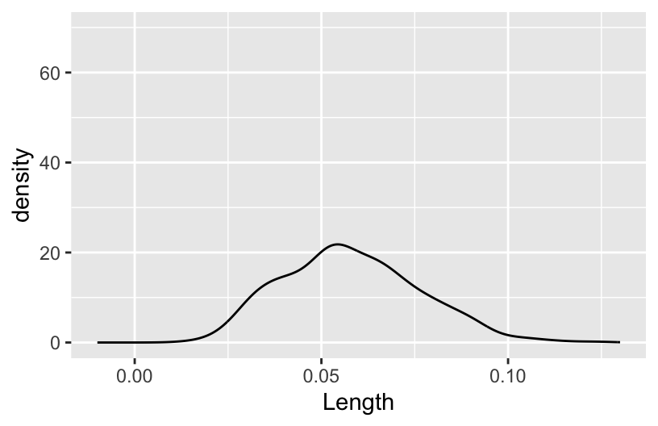

```r
# 500 sample slopes using samples of size 20
sample_models_20 %>%
  ggplot(aes(x = Length)) +
  geom_density() +
  lims(x = c(-0.01, 0.13), y = c(0, 70))
```

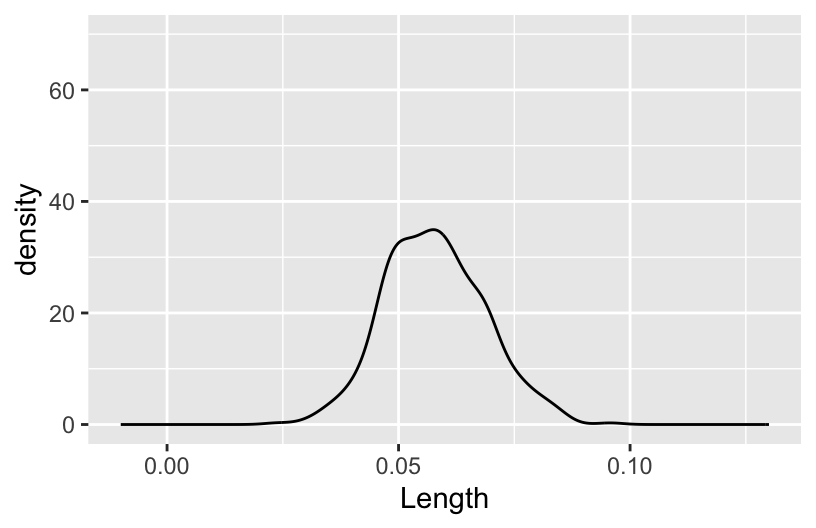

```r
# 500 sample slopes using samples of size 50
sample_models_50 %>%
  ggplot(aes(x = Length)) +
  geom_density() +
  lims(x = c(-0.01, 0.13), y = c(0, 70))
```

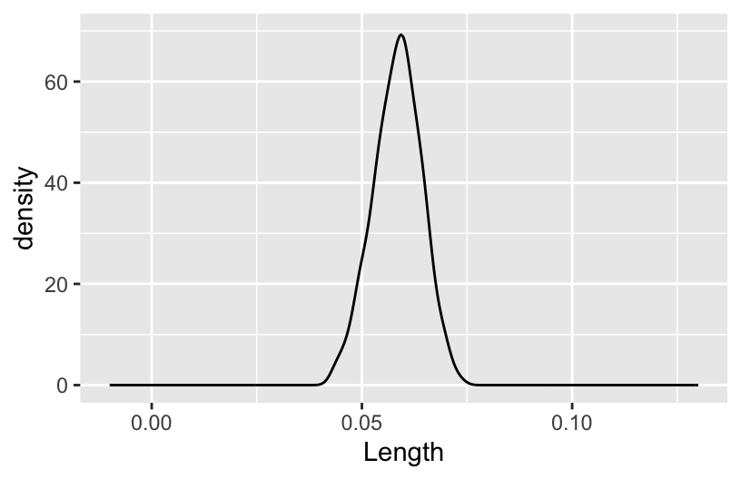

```r
# 500 sample slopes using samples of size 171
sample_models_boot %>%
  ggplot(aes(x = Length)) +
  geom_density() +
  lims(x = c(-0.01, 0.13), y = c(0, 70))
```

### Exercise 12: Properties of sampling distributions

In light of your observations, complete the following statements about the sampling distribution of the sample slope.

1. For all sample sizes, the shape of the sampling distribution is roughly ___ and the sampling distribution is roughly centered around ___, the sample estimate from our original data.
2. As sample size increases:  
   The average sample slope estimate INCREASES / DECREASES / IS FAIRLY STABLE.  
   The standard error of the sample slopes INCREASES / DECREASES / IS FAIRLY STABLE.
3. Thus, as sample size increases, our sample slopes become MORE RELIABLE / LESS RELIABLE.